# Examples using DBTPlotR and ggplot2

2024-06-20

This document demonstrates example usage of [`DBTPlotR`](https://gitlab.data.trade.gov.uk/dbt-data-visualisation-library/dbtplotr), and some fundamental principles of `ggplot2`. Details on the package can be found on the [package README](https://gitlab.data.trade.gov.uk/dbt-data-visualisation-library/dbtplotr#dbtplotr).

Start by installing the `ggplot2` and `dbtplotr` packages. As `dbtplotr` is an internal package, we install it using the `devtools` package. We also install `DBI` to connect to datasets on Data Workspace, and`dplyr` to manipulate this data.

```r
req <- c("ggplot2", "DBI", "dplyr")
to_install <- req[!(req %in% installed.packages()[,"Package"])]
if(length(to_install)) install.packages(to_install)

devtools::install_git("git@gitlab.data.trade.gov.uk:dbt-data-visualisation-library/dbtplotr.git", upgrade = 'never')

library(DBI)
library(dplyr)
library(ggplot2)
library(plotly)
library(dbtplotr)
```

Load in a dummy dataset…

```r
conn <- DBI::dbConnect(RPostgres::Postgres())

## ONS UK Total Trade
ons_trade <- dbGetQuery(conn,'SELECT * FROM ons.trade__uk_totals_sa;')

ons_trade_sk <- ons_trade %>%
  filter(period_type == 'year', ons_region_name == 'South Korea', period >= '2010', product_name == 'goods')
ons_trade_imports <- ons_trade %>%
  filter(period %in% c('2022'), product_name == 'goods', direction== 'imports', value > 100,
         ons_region_name %in% c('Bangladesh', 'Poland','Brazil','Australia','Mexico','India'))
```

### Example line chart

Let’s create a simple ggplot…

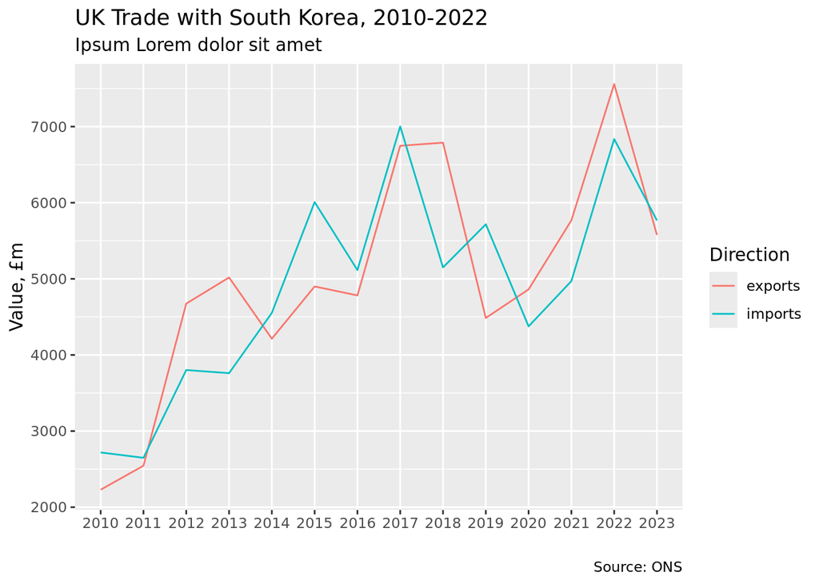

```r
ggplot(data = ons_trade_sk,
       aes(x = period, y = value, group = direction)) +
  geom_line(aes(color = direction)) +
  labs(title = "UK Trade with South Korea, 2010-2022",
       subtitle = "Ipsum Lorem dolor sit amet",
       caption = "Source: ONS",
       x = "",
       y = "Value, £m",
       color = "Direction")
```

Layer on the DBT theme using `+ theme_dbt()` and DBT colours using `+ colours_dbt()`. Here we set `palette = 'dbt2'` to use the DBT analysis function’s core 2 colours. See the full list of colour palettes [on the DBTPlotR ReadMe here](https://gitlab.data.trade.gov.uk/dbt-data-visualisation-library/dbtplotr#colour-palettes).

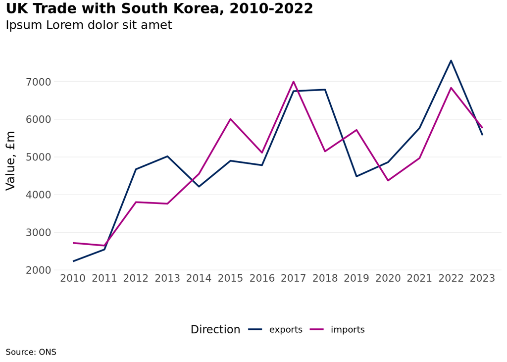

```r
ggplot(data = ons_trade_sk,
       aes(x = period, y = value, group = direction)) +
  geom_line(aes(color = direction)) +
  labs(title = "UK Trade with South Korea, 2010-2022",
       subtitle = "Ipsum Lorem dolor sit amet",
       caption = "Source: ONS",
       x = "",
       y = "Value, £m",
       color = "Direction") +
  theme_dbt() +
  colours_dbt(type = 'line', palette = 'dbt2')
```

Here is an example of layering on multiple geometries, `geom_line()` and `geom_point()`. Note that variables are mapped to aesthetics within `aes()` i.e. `geom_line(aes(color = direction))`, while fixed aesthetics are set outside i.e. `geom_point(color = 'blue')`.

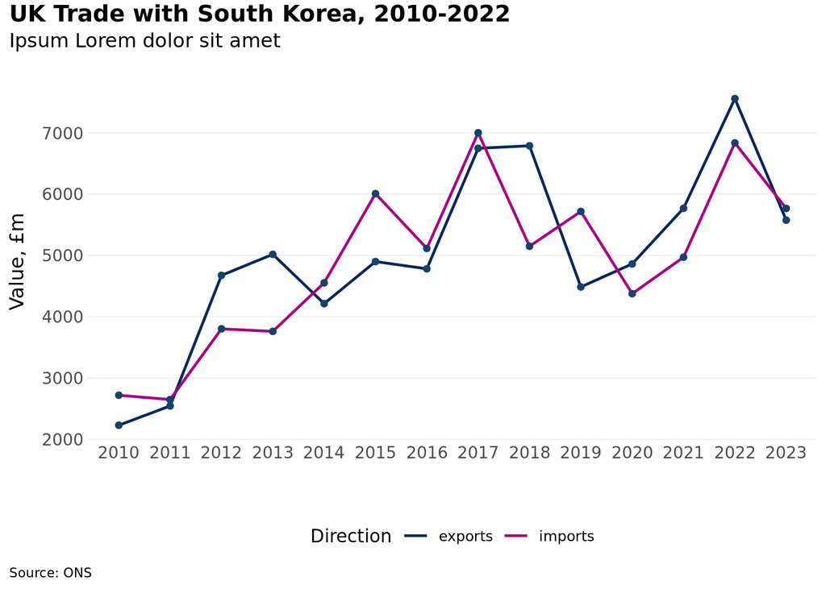

```r
ggplot(data = ons_trade_sk,
       aes(x = period, y = value, group = direction)) +
  geom_line(aes(color = direction)) +
  geom_point(color = "#12436D") +
  labs(title = "UK Trade with South Korea, 2010-2022",
       subtitle = "Ipsum Lorem dolor sit amet",
       caption = "Source: ONS",
       x = "",
       y = "Value, £m",
       color = "Direction") +
  theme_dbt() +
  colours_dbt(type = 'line', palette = 'dbt2')
```

### Example bar chart

Note we use `geom_bar(stat = 'identity')` to indicate that y-values (value of imports) are already aggregated and ready to plot. If, instead, we wished to plot the number of imports, and the dataframe consisted of multiple rows for each x-value (country), we would apply a statistical transformation `geom_bar(stat = 'count')` to tell `ggplot2` to count the cases for each country before plotting.

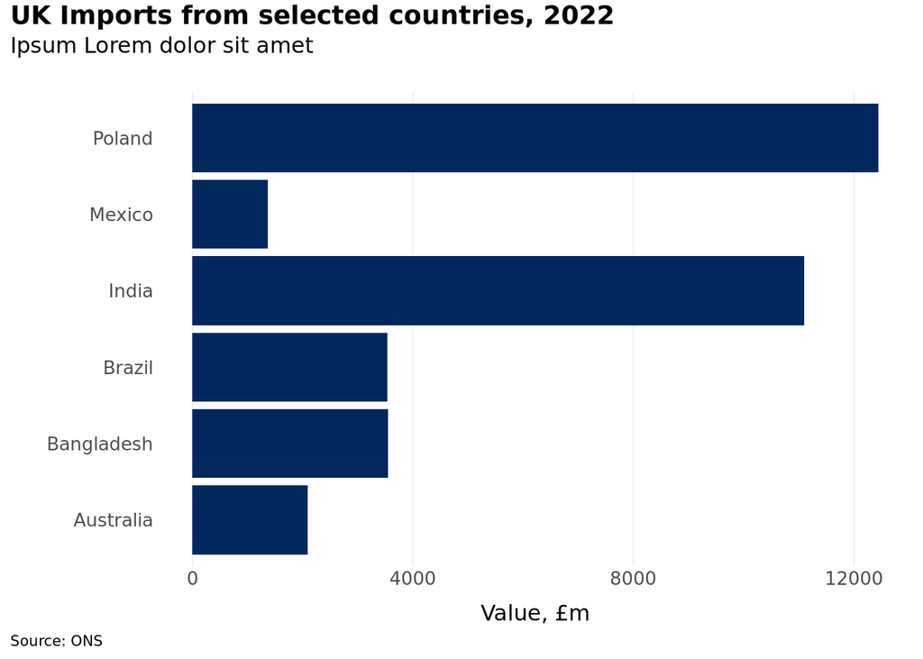

```r
ggplot(data = ons_trade_imports,
       aes(x = ons_region_name, y = value)) +
  geom_bar(stat = 'identity') +
  coord_flip() +
  labs(title = "UK Imports from selected countries, 2022",
       subtitle = "Ipsum Lorem dolor sit amet",
       caption = "Source: ONS",
       x = "",
       y = "Value, £m") +
  theme_dbt(gridline = 'x')
```

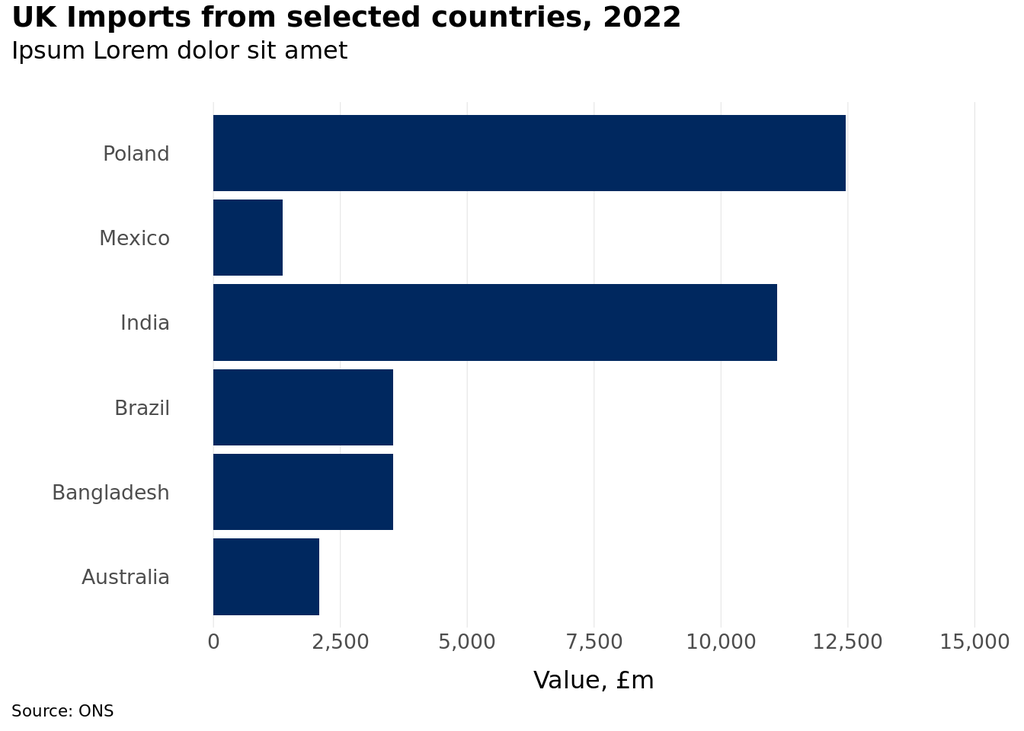

```r
ggplot(data = ons_trade_imports,
       aes(x = value, y = ons_region_name)) +
  geom_bar(stat = 'identity') +
  labs(title = "UK Imports from selected countries, 2022",
       subtitle = "Ipsum Lorem dolor sit amet",
       caption = "Source: ONS",
       y = "",
       x = "Value, £m") +
  theme_dbt(gridline = 'x', legend = 'none') +
  scale_x_continuous(label = scales::comma,
                     limits = c(0, 15000),
                     breaks=seq(0,15000,2500))
```

Switch between colour palettes by adjusting `colours_dbt()`. For example, here we emphasise a specific series (Brazil) by updating the aesthetics and using the two-colour DBT palette! Remove unnecessary legends and display only x-axis gridlines using `theme_dbt(gridline = 'x', legend='none')`.

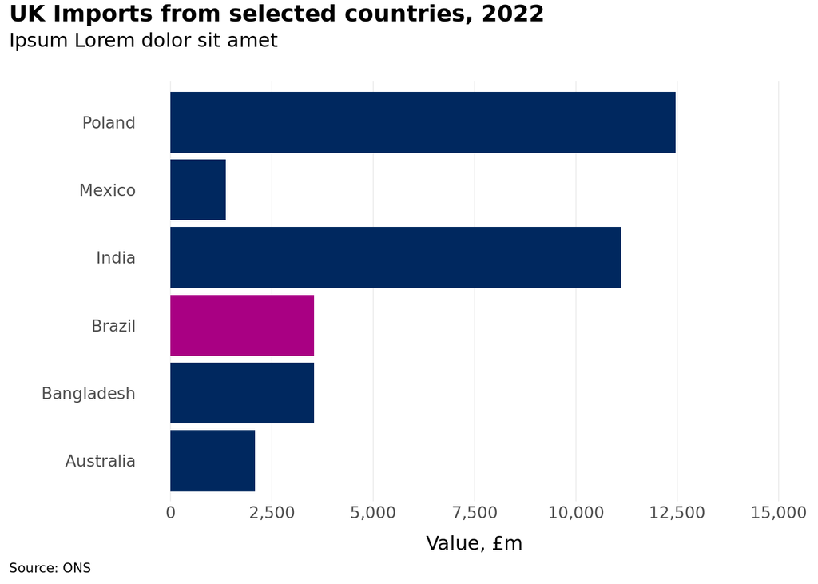

```r
ons_trade_imports %>%
  mutate(highlight = ifelse(ons_region_name == "Brazil", 1, 0)) %>%
  ggplot(aes(x = value, y = ons_region_name, fill = factor(highlight))) +
  geom_bar(stat = 'identity') +
  labs(title = "UK Imports from selected countries, 2022",
       subtitle = "Ipsum Lorem dolor sit amet",
       caption = "Source: ONS",
       y = "",
       x = "Value, £m") +
  theme_dbt(gridline = 'x', legend = 'none') +
  scale_x_continuous(label = scales::comma,
                     limits = c(0, 15000),
                     breaks=seq(0,15000,2500)) +
  colours_dbt(type = 'bar', palette = 'dbt2')
```

Finally, we can create facet plots using `facet_wrap()`…

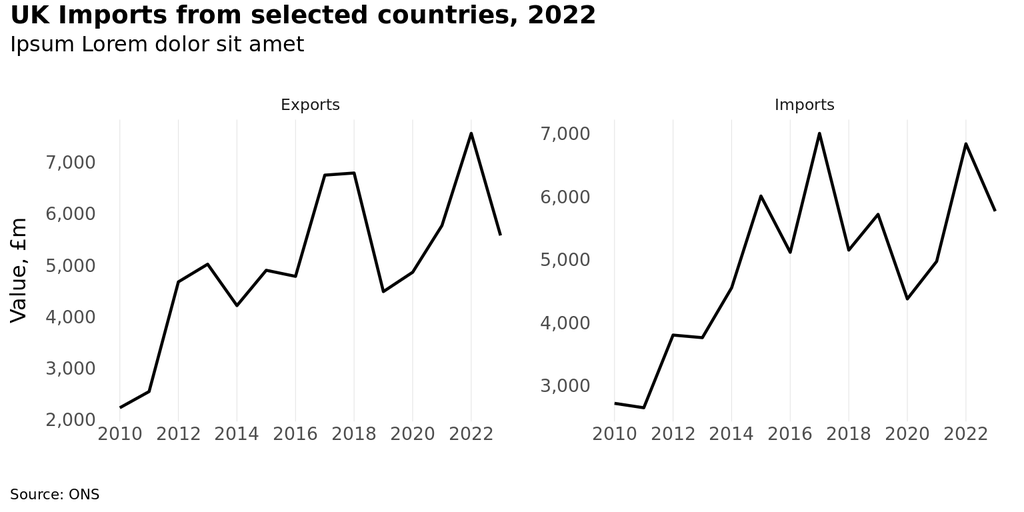

```r
# Tidy values for plotting
ons_trade_sk["direction"][ons_trade_sk["direction"] == "exports"] <- "Exports"
ons_trade_sk["direction"][ons_trade_sk["direction"] == "imports"] <- "Imports"

ons_trade_sk %>%
  mutate(period = as.numeric(period)) %>%
  ggplot(aes(x = period, y = value, group = 1)) +
  geom_line() +
  labs(title = "UK Imports from selected countries, 2022",
       subtitle = "Ipsum Lorem dolor sit amet",
       caption = "Source: ONS",
       x = "",
       y = "Value, £m") +
  theme_dbt(gridline = 'x', legend = 'none') +
  scale_y_continuous(label = scales::comma) +
  scale_x_continuous(breaks=seq(2010,2023,2)) +
  facet_wrap(~direction, scales = "free_y")
```

… and `facet_grid()`

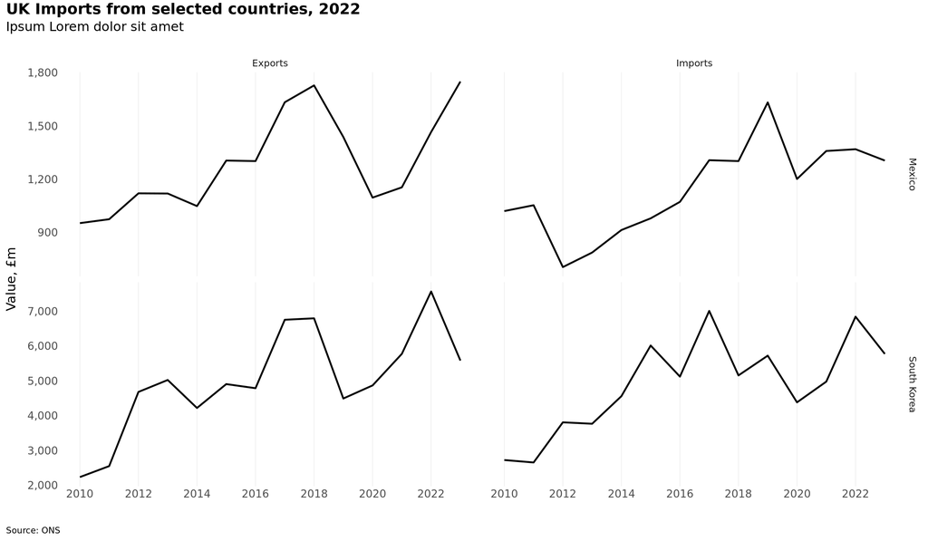

```r
ons_trade_two_countries <- ons_trade %>%
  filter(period_type == 'year', ons_region_name == 'South Korea' | ons_region_name == 'Mexico',
         period >= '2010', product_name == 'goods')

# Tidy values for plotting
ons_trade_two_countries["direction"][ons_trade_two_countries["direction"] == "exports"] <- "Exports"
ons_trade_two_countries["direction"][ons_trade_two_countries["direction"] == "imports"] <- "Imports"

ons_trade_two_countries %>%
  mutate(period = as.numeric(period)) %>%
  ggplot(aes(x = period, y = value, group = 1)) +
  geom_line() +
  labs(title = "UK Imports from selected countries, 2022",
       subtitle = "Ipsum Lorem dolor sit amet",
       caption = "Source: ONS",
       x = "",
       y = "Value, £m") +
  theme_dbt(gridline = 'x', legend = 'none') +
  scale_y_continuous(label = scales::comma) +
  scale_x_continuous(breaks=seq(2010,2023,2)) +
  facet_grid(ons_region_name ~ direction, scales = "free_y")
```